# Work 12 - Taxi date-time forecast

## Project description

Sweet Lift Taxi company has collected historical data on taxi orders at airports. To attract more drivers during peak hours, we need to predict the amount of taxi orders for the next hour. Build a model for such a prediction.

The RMSE metric on the test set should not be more than 48.

### Project instructions

1. Download the data and resample it by one hour.
2. Analyze the data.
3. Train different models with different hyperparameters. The test sample should be 10% of the initial dataset.
4. Test the data using the test sample and provide a conclusion.

### Data description

The data is stored in file `taxi.csv`. The number of orders is in the '*num_orders*' column.

# 1. Preparation

## Libraries

```python
import sklearn
import joblib
import pandas as pd
import numpy as np
import time
from joblib import dump
import matplotlib.pyplot as plt
from scipy import stats as st
import seaborn as sns
from sklearn.utils import shuffle
from sklearn.model_selection import train_test_split
from sklearn.tree import DecisionTreeClassifier, DecisionTreeRegressor
from sklearn.ensemble import RandomForestClassifier, RandomForestRegressor
from sklearn.linear_model import LogisticRegression, LinearRegression
from sklearn.metrics import accuracy_score, confusion_matrix, f1_score, recall_score
from sklearn.metrics import mean_squared_error, r2_score, mean_absolute_error, precision_score
from sklearn.metrics import roc_auc_score, precision_recall_curve, roc_curve
from sklearn.preprocessing import OrdinalEncoder, StandardScaler
from catboost import CatBoostClassifier,CatBoostRegressor
from lightgbm import LGBMRegressor
from xgboost import XGBRegressor
from statsmodels.tsa.seasonal import seasonal_decompose
```

## Reading and looking the data

```python
def get_precent_of_na_df(df,num):
    df_nulls = pd.DataFrame(df.isna().sum(),columns=['Missing Values'])
    df_nulls['Percent of Nulls %'] = round(df_nulls['Missing Values'] / df.shape[0],num) *100
    df_nulls = df_nulls.sort_values("Percent of Nulls %",ascending=False)
    return df_nulls

def Explore(df):
    df = df
    print(df.head())
    print("Number of duplicated rows",df.duplicated().sum())
    print("Data shape",df.shape)
    print('Columns with nulls:')
    display(get_precent_of_na_df(df,4))
    display(df.info())
    display(df.describe())
    print("Number of duplicated rows")
    display(df.duplicated().sum())
    temp_raw_data=df.copy()
    fig = plt.figure(figsize = (7,10))
    ax = fig.gca()
    temp_raw_data.hist(ax = ax)
    fig = ax.get_figure()
```

```
              datetime  num_orders
0  2018-03-01 00:00:00           9
1  2018-03-01 00:10:00          14
2  2018-03-01 00:20:00          28
3  2018-03-01 00:30:00          20
4  2018-03-01 00:40:00          32
Number of duplicated rows 0
Data shape (26496, 2)
Columns with nulls:
```

|  | Missing Values | Percent of Nulls % |
| --- | --- | --- |
| datetime | 0 | 0.0 |
| num_orders | 0 | 0.0 |

```
<class 'pandas.core.frame.DataFrame'>
RangeIndex: 26496 entries, 0 to 26495
Data columns (total 2 columns):
datetime      26496 non-null object
num_orders    26496 non-null int64
dtypes: int64(1), object(1)
memory usage: 414.1+ KB
```

```
None
```

|  | num_orders |
| --- | --- |
| count | 26496.000000 |
| mean | 14.070463 |
| std | 9.211330 |
| min | 0.000000 |
| 25% | 8.000000 |
| 50% | 13.000000 |
| 75% | 19.000000 |
| max | 119.000000 |

```
Number of duplicated rows
```

```
0
```

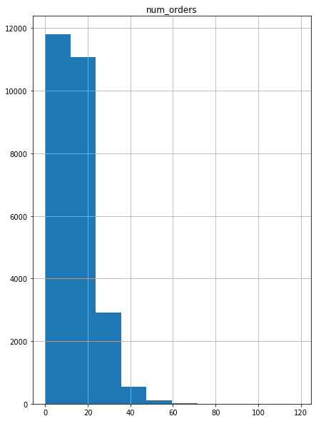

```python
df = pd.read_csv('/datasets/taxi.csv')
Explore(df)
# display(df.head())
# df.info()
# df.describe()
# print("Number of duplicated rows:",df.duplicated().sum())
```

### Data exploration conclusion

The data is simple. Two columns, one fiture and one target. We have a right sided tail distribution, with most of the time low passengers (10-20) and few times there are picks of over 20.

No null values or missing data. Date column should be datetime type.

## Preparing the data before introducing the model

```
                     num_orders
datetime
2018-03-01 00:00:00         124
2018-03-01 01:00:00          85
2018-03-01 02:00:00          71
2018-03-01 03:00:00          66
2018-03-01 04:00:00          43
Number of duplicated rows 4165
Data shape (4416, 1)
Columns with nulls:
```

|  | Missing Values | Percent of Nulls % |
| --- | --- | --- |
| num_orders | 0 | 0.0 |

```
<class 'pandas.core.frame.DataFrame'>
DatetimeIndex: 4416 entries, 2018-03-01 00:00:00 to 2018-08-31 23:00:00
Freq: H
Data columns (total 1 columns):
num_orders    4416 non-null int64
dtypes: int64(1)
memory usage: 69.0 KB
```

```
None
```

|  | num_orders |
| --- | --- |
| count | 4416.000000 |
| mean | 84.422781 |
| std | 45.023853 |
| min | 0.000000 |
| 25% | 54.000000 |
| 50% | 78.000000 |
| 75% | 107.000000 |
| max | 462.000000 |

```
Number of duplicated rows
```

```
4165
```

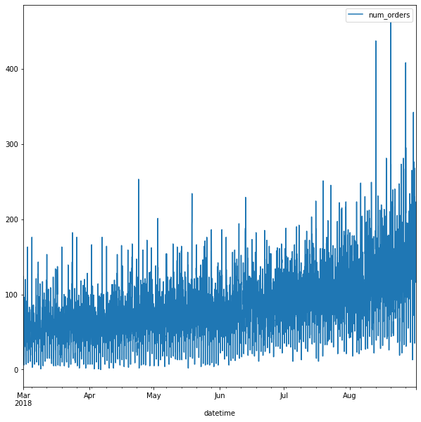

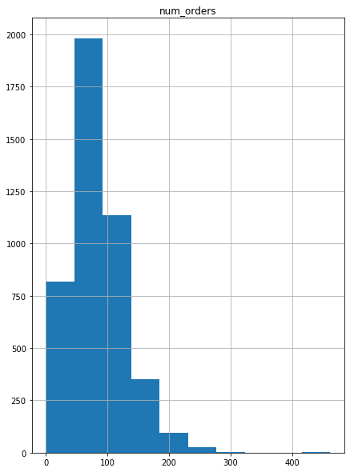

```python
df = pd.read_csv('/datasets/taxi.csv', index_col=[0], parse_dates=[0])
df.sort_index(inplace=True)
df = df.resample('1H').sum()
df.plot(figsize = (10,10))
Explore(df)
```

```
2018-03-01 00:00:00 2018-08-31 23:00:00
```

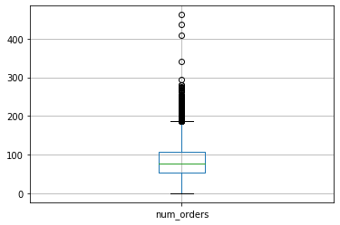

```python
df.boxplot()
print(df.index.min(), df.index.max())
```

# 2. Analysis

### First analysis

1. We can see that in total the trend is going up and more people are using taxis in general.
2. But, the use of taxis depends on the hour of the day, there is a seasonality on the use deppending on the hour of the day.
3. The variance between hours also get higher, so it is more important in this days to find the picks.
4. The minimum of passengeres per hour had not change during the last month, and even is getting higher than the beggining, although the variaty grew.
5. Some hours there are not even one passenger.
6. We have almost a right sided tail distribution, a bit normalized, but still the median is lower than the mean.
7. Most of the time average (85) amount of passengers (55-105) and few times there are picks of over 180.
8. A group of hours have picks between 180-300 PPH (passengers per hour)
9. The min and max of the time is March-August 2018

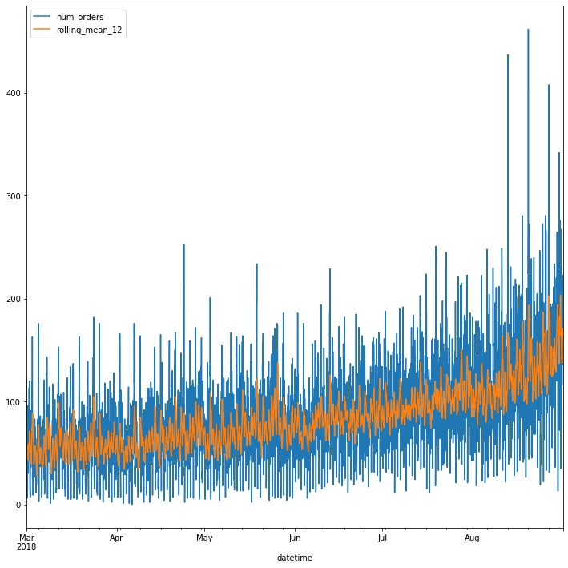

```python
# All data check with changes between day and night
df_plot_1 = df.copy()
df_plot_1['rolling_mean_12'] = df_plot_1['num_orders'].rolling(12).mean()
df_plot_1.plot(figsize = (12,12))
```

|  | num_orders | rolling_mean_12 |
| --- | --- | --- |
| count | 4416.000000 | 4405.000000 |
| mean | 84.422781 | 84.328320 |
| std | 45.023853 | 28.834198 |
| min | 0.000000 | 28.166667 |
| 25% | 54.000000 | 62.916667 |
| 50% | 78.000000 | 80.500000 |
| 75% | 107.000000 | 99.833333 |
| max | 462.000000 | 203.750000 |

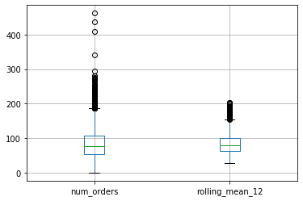

```python
df_plot_1.boxplot()
df_plot_1.describe()
```

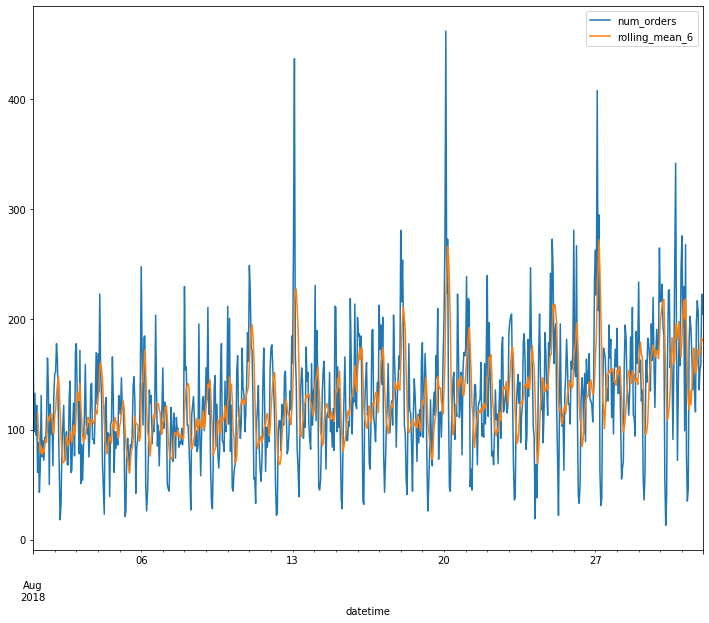

```python
# Last month check with changes per 6 hours a day
df_plot_2 = df.copy()
df_plot_2 = df_plot_2['2018-08-01':'2018-08-31']
df_plot_2['rolling_mean_6'] = df_plot_2.rolling(6).mean()
df_plot_2.plot(figsize = (12,10))
```

|  | num_orders | rolling_mean_6 |
| --- | --- | --- |
| count | 744.000000 | 739.000000 |
| mean | 127.651882 | 127.421516 |
| std | 56.242228 | 34.185170 |
| min | 13.000000 | 60.333333 |
| 25% | 91.000000 | 102.583333 |
| 50% | 122.000000 | 121.666667 |
| 75% | 160.000000 | 145.750000 |
| max | 462.000000 | 272.333333 |

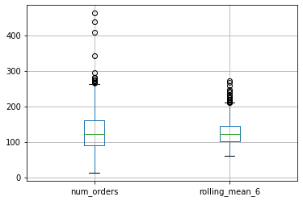

```python
df_plot_2.boxplot()
df_plot_2.describe()
```

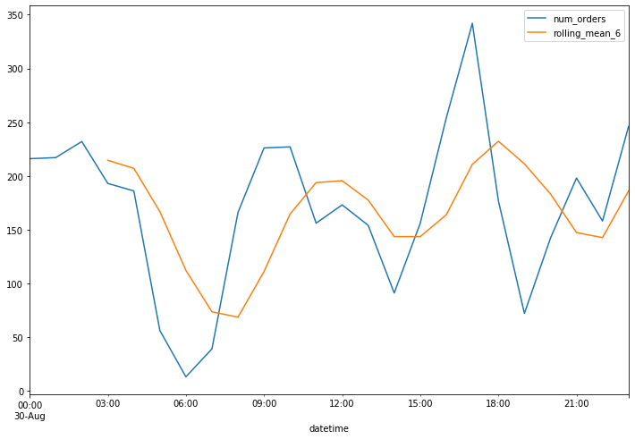

```python
# Last month check with changes per 6 hours a day
df_plot_3 = df.copy()
df_plot_3 = df_plot_3['2018-08-30':'2018-08-30']
df_plot_3['rolling_mean_6'] = df_plot_3.rolling(4).mean()
df_plot_3.plot(figsize = (12,8))
```

|  | num_orders | rolling_mean_6 |
| --- | --- | --- |
| count | 24.000000 | 21.000000 |
| mean | 170.416667 | 164.214286 |
| std | 75.422241 | 45.168178 |
| min | 13.000000 | 68.500000 |
| 25% | 151.000000 | 143.500000 |
| 50% | 175.000000 | 166.750000 |
| 75% | 219.250000 | 195.500000 |
| max | 342.000000 | 232.250000 |

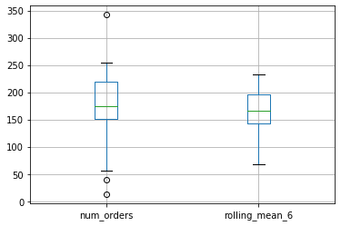

```python
df_plot_3.boxplot()
df_plot_3.describe()
```

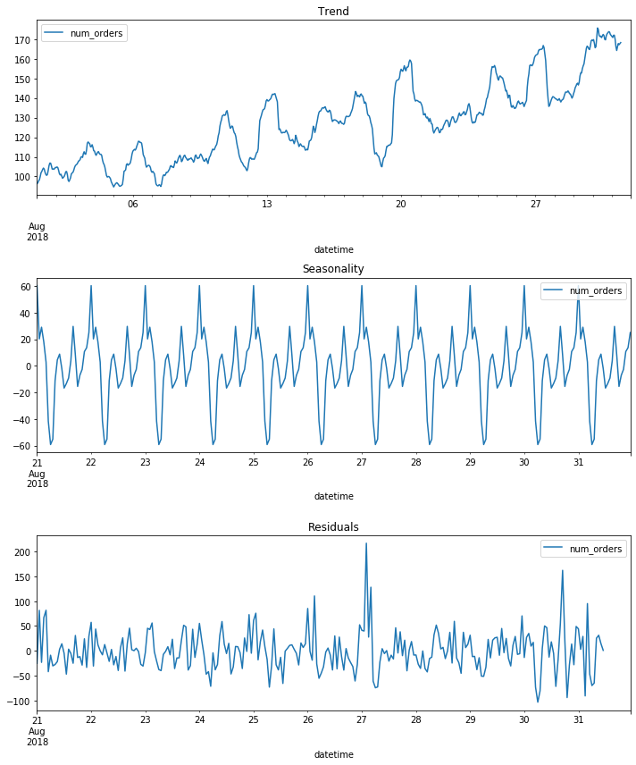

```python
# Seasonal decomposed check for last month or 10 days
decomposed = seasonal_decompose(df)
plt.figure(figsize=(10, 12))
plt.subplot(311)
decomposed.trend['2018-08-01':'2018-08-31'].plot(ax=plt.gca())
plt.title('Trend')
plt.subplot(312)
decomposed.seasonal['2018-08-21':'2018-08-31'].plot(ax=plt.gca())
plt.title('Seasonality')
plt.subplot(313)
decomposed.resid['2018-08-21':'2018-08-31'].plot(ax=plt.gca())
plt.title('Residuals')
plt.tight_layout()
```

# 3. Training

```python
def make_features(data, max_lag, rolling_mean_size):
    data['year'] = data.index.year
    data['month'] = data.index.month
    data['day'] = data.index.day
    data['dayofweek'] = data.index.dayofweek

    for lag in range(1, max_lag + 1):
        data['lag_{}'.format(lag)] = data['num_orders'].shift(lag)

    data['rolling_mean'] = data['num_orders'].shift().rolling(rolling_mean_size).mean()

df_daytime = df.copy()
make_features(df_daytime, 4, 1)
print(df_daytime.head())
```

```
                     num_orders  year  month  day  dayofweek  lag_1  lag_2  \
datetime
2018-03-01 00:00:00         124  2018      3    1          3    NaN    NaN
2018-03-01 01:00:00          85  2018      3    1          3  124.0    NaN
2018-03-01 02:00:00          71  2018      3    1          3   85.0  124.0
2018-03-01 03:00:00          66  2018      3    1          3   71.0   85.0
2018-03-01 04:00:00          43  2018      3    1          3   66.0   71.0

                     lag_3  lag_4  rolling_mean
datetime
2018-03-01 00:00:00    NaN    NaN           NaN
2018-03-01 01:00:00    NaN    NaN         124.0
2018-03-01 02:00:00    NaN    NaN          85.0
2018-03-01 03:00:00  124.0    NaN          71.0
2018-03-01 04:00:00   85.0  124.0          66.0
```

```python
train, test = train_test_split(df_daytime, shuffle=False, test_size=0.2)
train = train.dropna()
features_1 = train.drop(columns=['num_orders'], axis=1)
target_1 = train['num_orders']
features_test = test.drop(columns=['num_orders'], axis=1)
target_test = test['num_orders']

features_train, features_valid, target_train, target_valid = train_test_split(
    features_1, target_1, shuffle=False, test_size=0.2)

print('Size of features to train:', features_train.shape)
print('Size of features to validate:', features_valid.shape)
print('Size of features to test:', features_test.shape)
```

```
Size of features to train: (2822, 9)
Size of features to validate: (706, 9)
Size of features to test: (884, 9)
```

```python
def print_model_RMSE(mod):
    model = mod
    model.fit(features_train,target_train)
    predicted_valid = model.predict(features_valid)
    rmse_training = mean_squared_error(target_train, model.predict(features_train))**0.5
    rmse_valid = mean_squared_error(target_valid, predicted_valid)**0.5

    print("RMSE for the training set:", rmse_training)
    print("RMSE for the valid set: ", rmse_valid)
```

# 4. Testing

```python
%%time
model = DecisionTreeRegressor()
print('------------------ DecisionTreeRegressor ------------------')
print_model_RMSE(model)
```

```
------------------ DecisionTreeRegressor ------------------
RMSE for the training set: 0.0
RMSE for the valid set:  49.327416828691746
CPU times: user 27.8 ms, sys: 221 µs, total: 28 ms
Wall time: 25.3 ms
```

```python
%%time
model = RandomForestRegressor(random_state=12345)
print('------------------ RandomForestRegressor ------------------')
print_model_RMSE(model)
```

```
------------------ RandomForestRegressor ------------------
RMSE for the training set: 12.46708707353969
RMSE for the valid set:  36.28457753057403
CPU times: user 149 ms, sys: 0 ns, total: 149 ms
Wall time: 146 ms
```

```python
%%time
model = LinearRegression()
print('------------------ LinearRegression ------------------')
print_model_RMSE(model)
```

```
------------------ LinearRegression ------------------
RMSE for the training set: 27.865781484567705
RMSE for the valid set:  33.85897672423359
CPU times: user 23.5 ms, sys: 32.5 ms, total: 55.9 ms
Wall time: 17.8 ms
```

```python
%%time
model = CatBoostRegressor(loss_function="RMSE", verbose=False)
print('------------------ CatBoostRegressor ------------------')
print_model_RMSE(model)
```

```
------------------ CatBoostRegressor ------------------
RMSE for the training set: 19.657565004244418
RMSE for the valid set:  34.48518512745693
CPU times: user 23.5 s, sys: 3.39 s, total: 26.9 s
Wall time: 28.8 s
```

```python
%%time
model = XGBRegressor()
print('------------------ XGBRegressor ------------------')
print_model_RMSE(model)
```

```
------------------ XGBRegressor ------------------
[10:54:00] WARNING: /workspace/src/objective/regression_obj.cu:152: reg:linear is now deprecated in favor of reg:squarederror.
RMSE for the training set: 24.624635895632256
RMSE for the valid set:  34.46470817280574
CPU times: user 190 ms, sys: 6.46 ms, total: 197 ms
Wall time: 194 ms
```

Best 3 models including RMSE value and time running are RandomForestRegressor, XGBRegressor and LinearRegression. Lets trained hyperparameters.

```python
%%time
# Random Forest Regressor
print('------------------ RandomForestRegressor ------------------')
for estimators in range(10,101,10):
    print("Estimators =", estimators, ": ", end='')
    print('----------------------------------------------')
    model = RandomForestRegressor(n_estimators=estimators, random_state=12345)
    print_model_RMSE(model)
```

```
------------------ RandomForestRegressor ------------------
Estimators = 10 : ----------------------------------------------
RMSE for the training set: 12.46708707353969
RMSE for the valid set:  36.28457753057403
Estimators = 20 : ----------------------------------------------
RMSE for the training set: 11.20401140418036
RMSE for the valid set:  35.03173955435222
Estimators = 30 : ----------------------------------------------
RMSE for the training set: 10.909283457150996
RMSE for the valid set:  34.96239415931009
Estimators = 40 : ----------------------------------------------
RMSE for the training set: 10.665720131897476
RMSE for the valid set:  34.919493090511786
Estimators = 50 : ----------------------------------------------
RMSE for the training set: 10.580377864126435
RMSE for the valid set:  34.95677199363948
Estimators = 60 : ----------------------------------------------
RMSE for the training set: 10.54779067674767
RMSE for the valid set:  34.895882379146116
Estimators = 70 : ----------------------------------------------
RMSE for the training set: 10.515579139952608
RMSE for the valid set:  34.85720555984834
Estimators = 80 : ----------------------------------------------
RMSE for the training set: 10.476859194915987
RMSE for the valid set:  34.84325681983068
Estimators = 90 : ----------------------------------------------
RMSE for the training set: 10.432138561492692
RMSE for the valid set:  34.81179207065167
Estimators = 100 : ----------------------------------------------
RMSE for the training set: 10.388906222590125
RMSE for the valid set:  34.84033432114372
CPU times: user 7.74 s, sys: 0 ns, total: 7.74 s
Wall time: 7.78 s
```

```python
%%time
# XGB Regressor
print('------------------ XGBRegressor ------------------')
for depth in range(1,11,1):
    print("Depth =", depth, ": ", end='')
    print('----------------------------------------------')
    model = XGBRegressor(max_depth=depth, random_state=12345)
    print_model_RMSE(model)
```

```
------------------ XGBRegressor ------------------
Depth = 1 : ----------------------------------------------
[10:54:23] WARNING: /workspace/src/objective/regression_obj.cu:152: reg:linear is now deprecated in favor of reg:squarederror.
RMSE for the training set: 27.273239291187597
RMSE for the valid set:  34.85015436813807
Depth = 2 : ----------------------------------------------
[10:54:23] WARNING: /workspace/src/objective/regression_obj.cu:152: reg:linear is now deprecated in favor of reg:squarederror.
```

```
RMSE for the training set: 26.072832376127668
RMSE for the valid set:  34.555245703893014
Depth = 3 : ----------------------------------------------
[10:54:24] WARNING: /workspace/src/objective/regression_obj.cu:152: reg:linear is now deprecated in favor of reg:squarederror.
```

```
RMSE for the training set: 24.624635895632256
RMSE for the valid set:  34.46470817280574
Depth = 4 : ----------------------------------------------
[10:54:24] WARNING: /workspace/src/objective/regression_obj.cu:152: reg:linear is now deprecated in favor of reg:squarederror.
```

```
RMSE for the training set: 22.5106138164711
RMSE for the valid set:  34.925147087770476
Depth = 5 : ----------------------------------------------
[10:54:24] WARNING: /workspace/src/objective/regression_obj.cu:152: reg:linear is now deprecated in favor of reg:squarederror.
```

```
RMSE for the training set: 19.771101648918023
RMSE for the valid set:  34.92692496825781
Depth = 6 : ----------------------------------------------
[10:54:25] WARNING: /workspace/src/objective/regression_obj.cu:152: reg:linear is now deprecated in favor of reg:squarederror.
```

```
RMSE for the training set: 16.855866396648715
RMSE for the valid set:  35.320877641970114
Depth = 7 : ----------------------------------------------
[10:54:25] WARNING: /workspace/src/objective/regression_obj.cu:152: reg:linear is now deprecated in favor of reg:squarederror.
```

```
RMSE for the training set: 12.489130425545111
RMSE for the valid set:  35.47645915141579
Depth = 8 : ----------------------------------------------
[10:54:26] WARNING: /workspace/src/objective/regression_obj.cu:152: reg:linear is now deprecated in favor of reg:squarederror.
```

```
RMSE for the training set: 9.875449696990103
RMSE for the valid set:  36.31731561614266
Depth = 9 : ----------------------------------------------
[10:54:26] WARNING: /workspace/src/objective/regression_obj.cu:152: reg:linear is now deprecated in favor of reg:squarederror.
```

```
RMSE for the training set: 7.126427440695347
RMSE for the valid set:  36.51560020985621
Depth = 10 : ----------------------------------------------
[10:54:27] WARNING: /workspace/src/objective/regression_obj.cu:152: reg:linear is now deprecated in favor of reg:squarederror.
```

```
RMSE for the training set: 4.934161197207181
RMSE for the valid set:  35.90925710274751
CPU times: user 4.17 s, sys: 0 ns, total: 4.17 s
Wall time: 4.23 s
```

Now we will test our models on the test data.

```python
def print_model_RMSE_test(mod):
    model = mod
    model.fit(features_1,target_1)
    predicted_test = model.predict(features_test)
    rmse_training = mean_squared_error(target_1, model.predict(features_1))**0.5
    rmse_test = mean_squared_error(target_test, predicted_test)**0.5

    print("RMSE for the training set:", rmse_training)
    print("RMSE for the test set: ", rmse_test)
```

```python
%%time
model = LinearRegression()
print('------------------ LinearRegression ------------------')
print_model_RMSE_test(model)
```

```
------------------ LinearRegression ------------------
RMSE for the training set: 29.086986638623568
RMSE for the test set:  47.36406507365798
CPU times: user 12.6 ms, sys: 11.2 ms, total: 23.8 ms
Wall time: 8.35 ms
```

```
110.13555879866335
```

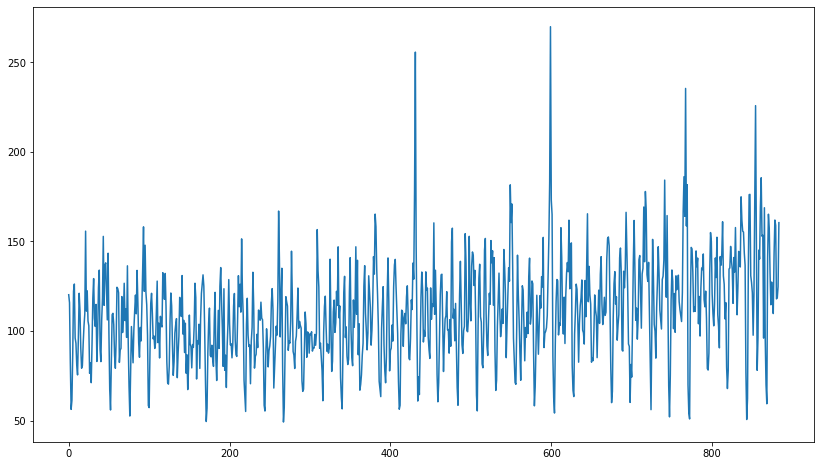

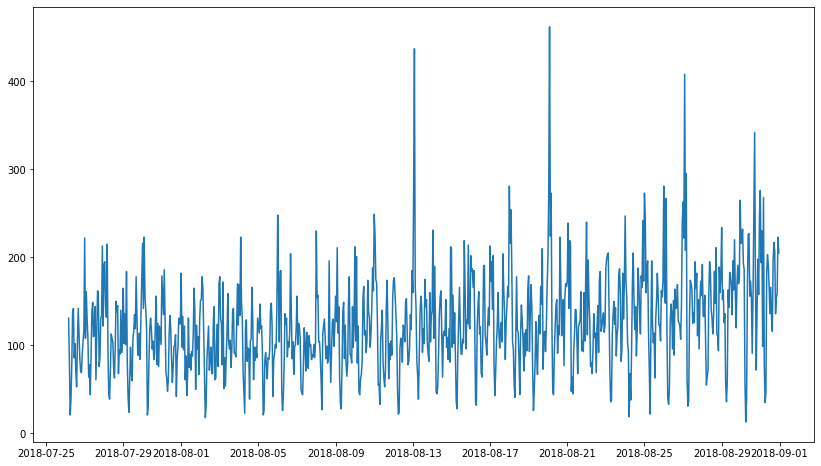

```python
model = LinearRegression()
model.fit(features_train,target_train)
predicted_test = model.predict(features_test)
print(predicted_test.mean())
plt.figure(figsize=(14, 8))
plt.plot(predicted_test)
plt.show()
plt.figure(figsize=(14, 8))
plt.plot(target_test)
plt.show()
```

## Conclusion

The best model, and aso fast one, is LinearRegression. Its RMSE is the lowest, and makes it the model with the best result.

Not only from the model, but also from the analysis, we saw that the trend of PPH is going up, thah before and after work is the picks, and also after midnight.

The model predicts the seasonability and the trend can be noticed. Still the average of the prediction is lower than the last month average, meanining that the model misses the trend.

```python
# Draft
pred_previous = test.shift()
pred_previous.iloc[0] = train.iloc[-1]
```